# MPA : TP3

2024-11-22

# PARTIE 1

## Question 1

On calcule $p(y \vert \theta)$.

On a :

$$\begin{align*}
p(y \vert \theta) & = \displaystyle \prod_{i = 1}^{n} p(y_i \vert
\theta) \\
& = \displaystyle \prod_{i = 1}^{n}
\dfrac{e^{-\theta}}{y_i!}\theta^{y_i} \\
& = e^{-n\theta} \displaystyle \prod_{i = 1}^{n}
\dfrac{\theta^{y_i}}{y_i!}
\end{align*}$$

## Question 2

Par la formule de Bayes,

$$\begin{align*}
p(\theta \vert y) & = \dfrac{p(y \vert \theta)p(\theta)}{p(y)} \\
& \propto p(y\vert \theta)p(\theta) \\
& \propto \dfrac{p(y\vert \theta)}{\theta} \\
& \propto e^{-n\theta} \dfrac{1}{\theta} \displaystyle \prod_{i =
1}^{n} \dfrac{\theta^{y_i }}{y_i!} \\
& \propto e^{-n\theta} \theta^{\displaystyle \sum_{i=1}^{n}
\left(y_i\right) - 1}
\end{align*}$$

La distribution Gamma peut être représentée avec les paramètres $\alpha$ et $\beta$ par :
$$f(\theta;\alpha,\beta) = \theta^{\alpha-1}\dfrac{\beta^{\alpha}e^{-\beta
\theta}}{\Gamma(\alpha)}$$

Ainsi, on reconnaît une loi Gamma de paramètre Gamma$\left(\displaystyle \sum_{i=1}^{n} y_i, n \right)$

L’espérance d’une loi Gamma vaut $\frac{\alpha}{\beta}$, ici $\mathbb{E}(\theta|y)=\frac{\sum_{i=1}^{n} y_i}{n}$

## Question 3

Algorithme de Metropolis-Hastings :

On initialise une valeur quelconque de $\theta^{(0)}$.  
À chaque itération, on tire une valeur $\theta^*$ selon une loi instrumentale que l’on note $q(\theta^t \vert \theta^*)$.  
On calcule un ratio $r = \dfrac{\pi(\theta^*)q(\theta^* \vert \theta^{t})}{\pi(\theta^t)q(\theta^{t} \vert \theta^*)}$.  
Alors, avec la probabilité $r$ (probabilité 1 si $r \geq 1$), on prend $\theta^{t+1} = \theta^*$, sinon on prend $\theta^{t}$. On continue pour un nombre d’itérations donné.

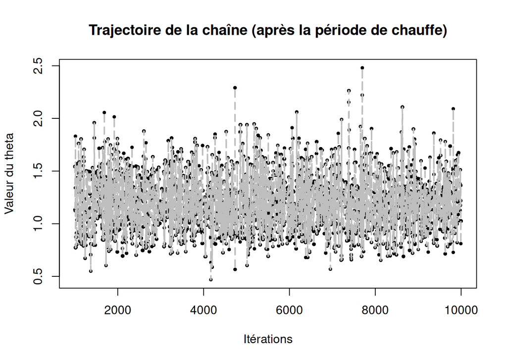

```r
#Initialisation

theta0 <- 1
Niterations <- 10000
n <- 20

loi_instrumentale <- function(thetat,thetastar){
  # L'énoncé suggère d'utiliser une loi exponentielle
  return(dexp(thetastar, 1 / thetat))
}

loi_theta_sach_y_prop <- function(theta,y){
  return(exp(-n*theta) * theta^(sum(y) - 1) * n^(sum(y)))
}

metropolis_hastings <- function(Niterations, theta_initial, y){

  theta <- numeric(Niterations)
  theta[1] <- theta_initial

  for (i in 2:Niterations){

    # L'énoncé suggère d'utiliser une loi exponentielle
    thetastar <- rexp(1, rate = 1 / theta[i - 1])
    ratio <- ( loi_theta_sach_y_prop(thetastar,y)*loi_instrumentale(thetastar,theta[i-1]) ) / (loi_theta_sach_y_prop(theta[i-1],y) * loi_instrumentale(theta[i-1],thetastar))
    # Sélection d'un nouveau theta ^ t+1
    if (runif(1) < min(1,ratio)){
      theta[i] <- thetastar
    }
    else{
      theta[i] <- theta[i-1]
    }

  }
  fin_periode_chauffe = floor(Niterations/10)
  # Trajectoire de la chaîne
  plot(fin_periode_chauffe:Niterations,theta[fin_periode_chauffe:Niterations], cex = .5, pch = 19, xlab = "Itérations", ylab = "Valeur du theta", main = "Trajectoire de la chaîne (après la période de chauffe)")
  points(fin_periode_chauffe:Niterations, theta[fin_periode_chauffe:Niterations], type = "l", lty = 2, lwd = 2, col = "grey")

  return(theta[fin_periode_chauffe:Niterations])
}

y_test <- rpois(n, lambda = 1)

theta_estime <- metropolis_hastings(Niterations, 1, y_test)
```

## Question 4

```r
cat("Moyenne a posteriori de theta :", mean(theta_estime), "\n")
```

```
## Moyenne a posteriori de theta : 1.196759
```

```r
cat("Médiane a posteriori de theta :", median(theta_estime), "\n")
```

```
## Médiane a posteriori de theta : 1.1789
```

```r
cat("Intervalle de crédibilité de 95% :", quantile(theta_estime, c(0.025, 0.975) ), "\n")
```

```
## Intervalle de crédibilité de 95% : 0.7817798 1.711487
```

## Question 5

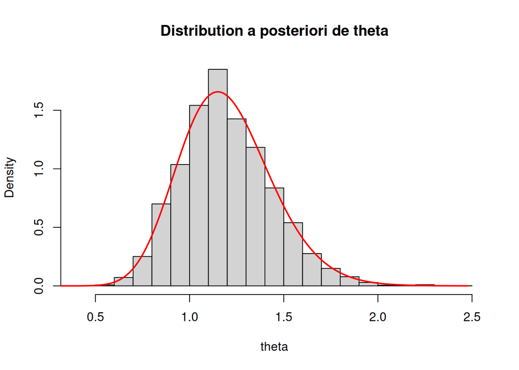

```r
hist(theta_estime, xlab = "theta", main = "Distribution a posteriori de theta", probability = TRUE )
x <- seq(0, max(theta_estime),length = Niterations)
# La loi obtenue à la question 2 est une loi gamma
y <- dgamma(x, shape = sum(y_test), rate = n)
lines(x, y, col = "red", lwd = 2)
```

## Question 6

Supposons que l’on possède des données $y$.

Par soucis de lisibilité, on remplace dans la suite le terme $\displaystyle \sum_{i=1}^{n}y_i$ par $\sum y_i$.

On a :

$$\begin{align*}
p(\tilde{y} \vert y) & = \displaystyle \int_{\mathbb{R}_{+}}
p(\tilde{y} \vert \theta, y)p(\theta \vert y) \operatorname{d}\theta \\
& = \displaystyle \int_{\mathbb{R}_{+}} \dfrac{e^{-\theta}
\theta^{\tilde{y}}}{\tilde{y}!}.\dfrac{n^{ \sum y_i}\theta^{\sum y_i -
1}e^{-n\theta}}{\Gamma(\sum y_i)} \operatorname{d}\theta \\
& = \dfrac{n^{ \sum y_i}}{\tilde{y}!\Gamma(\sum y_i) } \displaystyle
\int_{\mathbb{R}_{+}} e^{-\theta} \theta^{\tilde{y}}.\theta^{\sum y_i -
1}e^{-n\theta} \operatorname{d}\theta \\
& = \dfrac{n^{ \sum y_i}}{\tilde{y}!\Gamma(\sum y_i) } \displaystyle
\int_{\mathbb{R}_{+}} e^{-(n+1)\theta} \theta^{\tilde{y} + \sum y_i - 1}
\operatorname{d}\theta \\
& = \dfrac{n^{ \sum y_i}}{\tilde{y}!\Gamma(\sum y_i)
(n+1)^{\tilde{y} + \sum y_i} } \displaystyle \int_{\mathbb{R}_{+}}
e^{-\theta} \theta^{\tilde{y} + \sum y_i - 1} \operatorname{d}\theta \
\text{(Changement de variable } u = (n+1)\theta) \\
& = \dfrac{n^{ \sum y_i}\Gamma(\tilde{y} + \sum y_i
)}{\tilde{y}!\Gamma(\sum y_i) (n+1)^{\tilde{y} + \sum y_i}}
\end{align*}$$

Or on sait que $\dfrac{\Gamma(\tilde{y} + \sum y_i )}{\tilde{y}!\Gamma(\sum y_i)} = \binom{\tilde{y} + \sum y_i - 1}{\tilde{y}}$

Ainsi :

$$\begin{align*}
p(\tilde{y} \vert y) & = \dfrac{n^{ \sum y_i}\Gamma(\tilde{y} + \sum
y_i )}{\tilde{y}!\Gamma(\sum y_i) (n+1)^{\tilde{y} + \sum y_i}} \\
& = \binom{\tilde{y} + \sum y_i - 1}{\tilde{y}} \dfrac{n^{ \sum
y_i}}{(n+1)^{\tilde{y} + \sum y_i}} \\
& = \binom{\tilde{y} + \sum y_i -
1}{\tilde{y}}.\left(\dfrac{1}{n+1}\right)^{\tilde{y}}.\left(\dfrac{n}{n+1}\right)^{\sum
y_i}
\end{align*}$$

La loi binomiale négative de paramètre $\mathcal{NB}(n,p,q = 1-p)$ a pour fonction de masse $P(X = k) = \binom{k + n - 1}{k}p^n q^k$

Avec ici $k = \tilde{y}$. On identifie donc une loi binomiale négative de paramètre $\mathcal{NB}\left(\sum y_i, \dfrac{n}{n+1}\right)$.

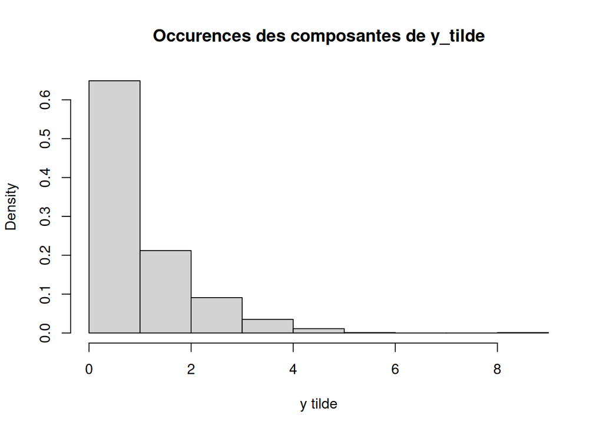

```r
algorithme_y_tilde <- function(y, N) {

  r <- sum(y)
  p <- n / (n + 1)
  y_tilde <- rnbinom(N, size = r, prob = p)

  return(y_tilde)
}

y_tilde <- algorithme_y_tilde(y_test,1000)

hist(y_tilde, xlab = "y tilde", main = "Occurences des composantes de y_tilde", probability = TRUE, breaks = 10 )
```

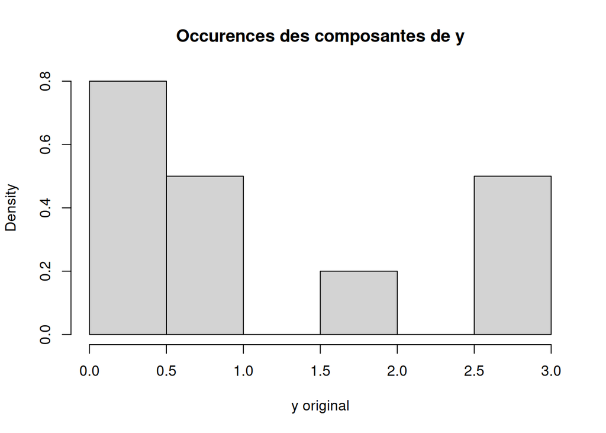

```r
hist(y_test, xlab = "y original", main = "Occurences des composantes de y", probability = TRUE, breaks = 10 )
```

```r
cat("La moyenne des prévisions vaut ", mean(y_test))
```

```
## La moyenne des prévisions vaut  1.2
```

```r
cat("\nL'écart-type des prévisions vaut ", sd(y_test))
```

```
##
## L'écart-type des prévisions vaut  1.239694
```

```r
cat("\nLa moyenne des observations vaut ", mean(y_tilde))
```

```
##
## La moyenne des observations vaut  1.246
```

```r
cat("\nL'écart-type des observations vaut ", sd(y_tilde))
```

```
##
## L'écart-type des observations vaut  1.186124
```

# PARTIE 2

## Question 1

On a :
$$\begin{align*}
p(y \vert z, \theta) &= \prod_{i=1}^{n} p(y_i \vert z_i, \theta) \\
p(y \vert z, \theta) &= \prod_{i=1}^{n} \frac{(\theta_{z_i})^{y_i}
e^{-\theta_{z_i}}}{y_i !} \\
p(y \vert z, \theta) &= \prod_{k=1}^{K} \prod_{i \in
I_k} \frac{(\theta_{k})^{y_i} e^{-\theta_{k}}}{y_i !} \\
\end{align*}$$

## Question 2

On pose pour tout k, $card(I_k) = \vert I_k \vert$
$$\begin{align*}
p((z,\theta) \vert y) &= \frac{p(y, z, \theta)}{p(y)} \\
p((z,\theta) \vert y) &= \frac{p(y\vert (z, \theta)) p((z,
\theta))}{p(y)} \\
p((z,\theta) \vert y) &= \frac{p(y\vert (z, \theta)) p(z)
p(\theta)}{p(y)} && \text{Par indépendance du couple}\\
p((z,\theta) \vert y) &\propto p(\theta)p(y \vert (z, \theta)) \\
p((z,\theta) \vert y) &\propto (\prod_{k=1}^{K} \frac{1}{\theta_k})
\prod_{k=1}^{K} \prod_{i \in I_k} \frac{(\theta_{k})^{y_i}
e^{-\theta_{k}}}{y_i !}\\
p((z,\theta) \vert y) &\propto (\prod_{k=1}^{K} \frac{1}{\theta_k})
\prod_{k=1}^{K} \theta_{k}^{\sum_{i \in I_k} y_i} \frac{e^{-\theta_k
\vert I_k \vert}}{\prod_{i \in I_k} y_i !}\\
p((z,\theta) \vert y) &\propto\prod_{k=1}^{K} \theta_{k}^{(\sum_{i
\in I_k} y_i) -1} e^{-\theta_k \vert I_k \vert}\\
\end{align*}$$

On reconnaît une loi Gamma de paramètres $Gamma(\sum_{i \in I_k} y_i, \vert I_k \vert)$ pour chaque $(z, \theta_k \vert y)$. On en déduit que la loi a posteriori du vecteur de variables $(z,\theta)$ peut être décrite comme suivant la loi $\prod_{i=1}^{K} Gamma(\sum_{i \in I_k}^K y_i, \vert I_k \vert)$

## Question 3 :

On a :
$$\begin{align*}
p(z_i = k \vert y, \theta) &= \frac{p(y_i \vert z_i = k ,
\theta)p(z_i = k \vert \theta)}{p(y_i \vert \theta)} \\ \text{par
mutuelle indépendance des $(\theta_k, z_i)$, on a }
p(z_i = k \vert y, \theta) &\propto p(y_i \vert z_i = k ,
\theta)\underbrace{p(z_i = k)}_{\propto 1} \\
p(z_i = k \vert y, \theta) &\propto \theta_{k}^{y_i} e^{-\theta_{k}}
\end{align*}$$

La constante de normalisation se trouve en divisant par la somme des probabilités $\sum_{k=1}^{K}p(z_i = k\vert y, \theta)$. On a donc, $p(z_i = k \vert y, \theta) = \frac{\theta_{k}^{y_i} e^{-\theta_{k}}}{\sum_{n=1}^{K}\theta_{n}^{y_i} e^{-\theta_{n}}}$.

## Question 4 :

On a :
$$\begin{align*}
P(\theta_k \vert \theta_{-k}, y, z) &\propto p(\theta_k \vert
y_k,z_k) && \text{car $\theta_k$ ne dépend pas de
$\theta_{-k}$ ni de $y_{-k}$ ni de $z_{-k}$ } \\
P(\theta_k \vert \theta_{-k}, y, z) &\propto p(y_k \vert z_k,
\theta_k) p(\theta_k \vert z_k) \\
P(\theta_k \vert \theta_{-k}, y, z) &\propto \frac{p(y_k \vert z_k,
\theta_k)}{\theta_k} \\
P(\theta_k \vert \theta_{-k}, y, z) &\propto \frac{1}{\theta_k}
\prod_{i \in I_k} \frac{(\theta_{k})^{y_i} e^{-\theta_{k}}}{y_i !} \\
P(\theta_k \vert \theta_{-k}, y, z) &\propto \frac{1}{\theta_k}
\prod_{i \in I_k} (\theta_{k})^{y_i} e^{-\theta_{k}} \\
P(\theta_k \vert \theta_{-k}, y, z) &\propto \theta_{k}^{(\sum_{i
\in I_k} y_i) -1} e^{-n_k \theta_{k}} \\
P(\theta_k \vert \theta_{-k}, y, z) &\propto \theta_{k}^{n_k
\bar{y_k} -1} e^{-n_k \theta_{k}}
\end{align*}$$

## Question 5 :

Pour l’algorithme d’échantillonnage de Gibbs pour la loi à postériori $(z,\theta)$. On commence par initialiser le vecteur $\theta⁰$ arbitrairement. On génère ensuite $y$ et $z⁰$. Pour une itération, on génère d’abord les $\theta_k$ selon la loi $Gamma(n_k\bar{y_k}, n_k)$ de la question 4. On simule le vecteur $z$ selon la loi conditionnelle de la question 3.

```r
# Initialisation
n <- 2000
K <- 50
theta_0 <- sample(1:10, size = K, replace = TRUE)
y <- rpois(n,theta_0)


# Paramètres à l'itération t
theta_t <- sample(1:10, size = K, replace = TRUE)

z_t <- integer(n)

# Simuler z_i pour chaque y_i
for (i in 1:n) {
  # Calcul des poids pour chaque k
  probs <- theta_t^y[i] * exp(-theta_t)


  # Simuler z_i à partir des probabilités
  z_t[i] <- sample(1:K, size = 1, prob = probs)
}

# itération t+1
for (k in 1:K){
  I_k <- vector("list", K)  # Liste pour regrouper les y par cluster
  for (i in 1:K) {
    I_k[[i]] <- y[z_t == i]  # Ajoute les y[j] où z[j] == i
  }
  n_k <- length(I_k[[k]])  # Nombre d'observations dans le cluster k
  sum_y_k <- sum(I_k[[k]])  # Somme des y[j] dans le cluster k
  theta_t[k] <- rgamma(1,sum_y_k,n_k)
}

for (i in 1:n) {
  # Calcul des poids pour chaque k
  probs <- theta_t^y[i] * exp(-theta_t)


  # Simuler z_i à partir des probabilités
  z_t[i] <- sample(1:K, size = 1, prob = probs)
}
```

## Question 6

On peut estimer l’espérance de $\theta_k$ sachant $y$ en prenant la moyenne empirique des simulations de $\theta_k$, en effectuant l’algorithme de la question 5 un grand nombre de fois.

On estime la proportion de chacune des composantes du mélange en effectuant le ratio entre le nombre de valeurs dans le cluster k $\in {1,...,K}$ et le nombre total de valeurs.

## Question 7

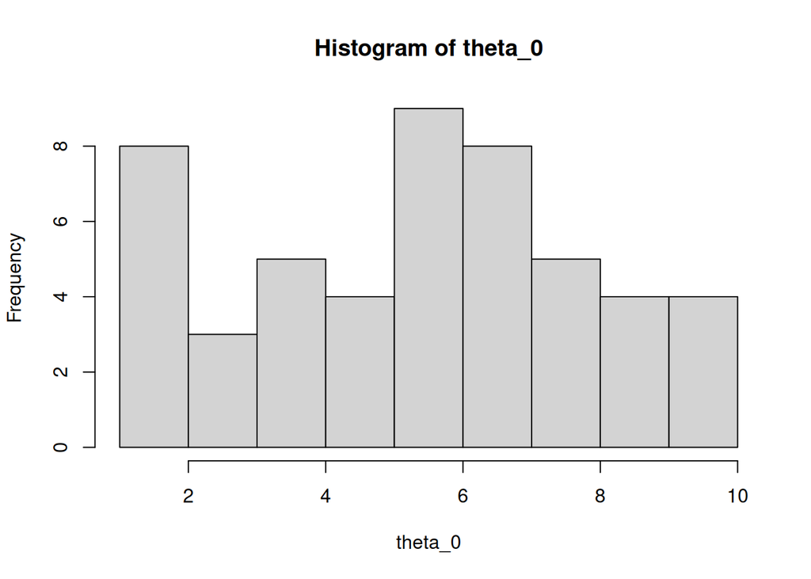

```r
hist(theta_0)
```

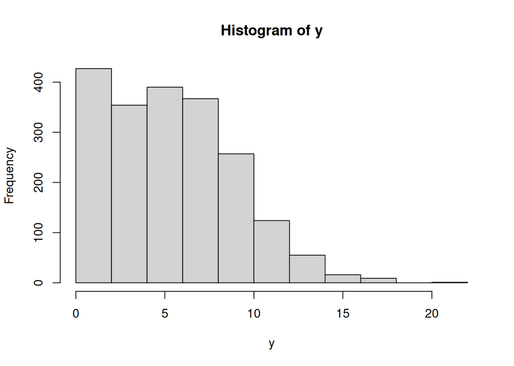

```r
hist(y)
```

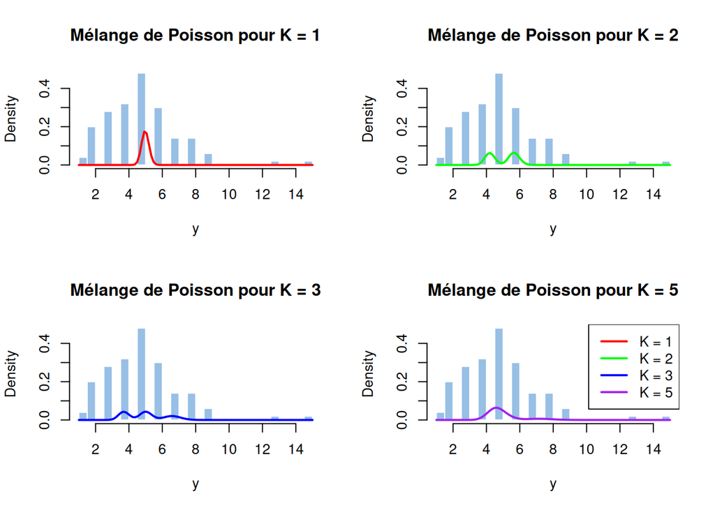

```r
# Exemple de données y
n <- 100
y <- rpois(n, lambda = 5)  # Générer les observations y (loi de Poisson)

# Fonction de Gibbs pour le modèle de mélange de Poisson
gibbs <- function(K, N_iter, y) {
  theta0 <- rgamma(K, shape = 1, rate = 1) # Initialisation des valeurs de theta
  theta <- theta0
  z <- sample(1:K, size = n, replace = TRUE)  # Initialisation des clusters z

  # Algorithme de Gibbs
  for (t in 1:N_iter) {
    # Mise à jour des paramètres theta
    for (k in 1:K) {
      n_k <- sum(z == k)  # Nombre d'observations dans le cluster k
      sum_y_k <- sum(y[z == k])  # Somme des y[j] dans le cluster k
      theta[k] <- rgamma(1, shape = sum_y_k, rate = n_k)  # Mettre à jour theta_k
    }

    # Mise à jour des assignations z
    for (i in 1:n) {
      probs <- theta^y[i] * exp(-theta)  # Calcul des probabilités
      probs <- probs / sum(probs)  # Normalisation pour obtenir des probabilités valides
      z[i] <- sample(1:K, size = 1, prob = probs)  # Assigner z_i à un cluster
    }
  }

  return(list(z = z, theta = theta,theta0=theta0))  # Retourner les résultats
}

# Essai de plusieurs valeurs de K
K_values <- c(1, 2, 3, 5)  # Valeurs de K à tester
N_iter <- 1000  # Nombre d'itérations de l'algorithme Gibbs

# Définir les couleurs pour chaque courbe
colors <- c("red", "green", "blue", "purple")

# Initialiser la disposition des graphiques (4 graphiques côte à côte)
par(mfrow = c(2, 2))  # 2 lignes, 2 colonnes pour les graphiques

# Tracer les lois de mélange pour différentes valeurs de K
for (i in 1:length(K_values)) {
  K <- K_values[i]
  result <- gibbs(K, N_iter, y)  # Appliquer Gibbs pour chaque valeur de K
  theta <- result$theta

  # Fonction pour calculer la densité de la loi de mélange estimée par Gibbs
  mix_density <- function(x) {
    dens <- 0
    for (k in 1:K) {
      dens <- dens + 0.1*dgamma(x, shape = sum(y[result$z == k]), rate = sum(result$z == k)) * mean(result$z == k)
    }
    return(dens)
  }

  # Tracer l'histogramme des données
  hist(y, breaks = 30, main = paste("Mélange de Poisson pour K =", K),
       xlab = "y", col = rgb(0.2, 0.5, 0.8, 0.5), border = "white", freq = FALSE)

  # Superposer la loi de mélange estimée
  curve(mix_density(x), from = min(y), to = max(y), col = colors[i], lwd = 2, add = TRUE)
}

# Ajouter une légende pour identifier les différentes courbes
legend("topright", legend = paste("K =", K_values), col = colors, lwd = 2)
```

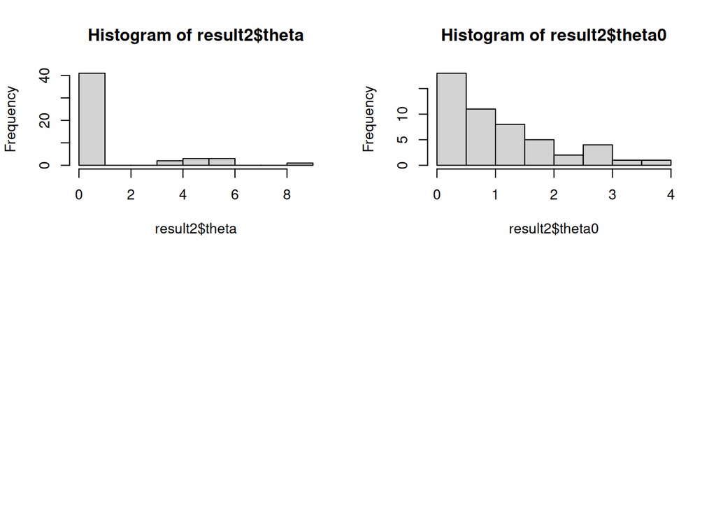

```r
result2 <- gibbs(50,1000,y)
hist(result2$theta)
hist(result2$theta0)
```